# basic generalized linear models

Ben Bolker

Licensed under the [Creative Commons attribution-noncommercial license](http://creativecommons.org/licenses/by-nc/3.0/). Please share & remix noncommercially, mentioning its origin.

```r
library(ggplot2); theme_set(theme_bw())
library(ggExtra)
library(cowplot)
library(dotwhisker)
```

# From Linear to generalized linear models

## Why GLMs?

- assumptions of linear models do break down sometimes
- count data: discrete, non-negative
- proportion data: discrete counts, $0 \le x \le N$
- hard to transform to Normal
- linear model doesn’t make sense

[figure not shown]

## GLMs in action

- vast majority of GLMs
  - *logistic regression* (binary/Bernoulli data)
  - *Poisson regression* (count data)
- lots of GLM theory carries over from LMs
  - formulas
  - parameter interpretation (partly)
  - diagnostics (partly)

## Most GLMs are logistic

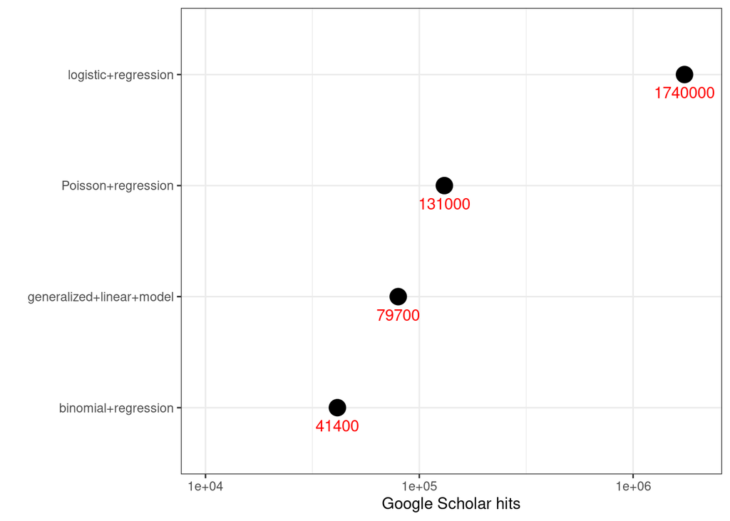

## Family

- family: what kind of data do I have?
  - from **first principles**: family specifies the relationship between the mean and variance
  - binomial: proportions, out of a total number of counts; includes binary (Bernoulli) (“logistic regression”)
  - Poisson (independent counts, no maximum, or far from the maximum)
  - other (Normal (`"gaussian"`), Gamma)
- default family for `glm` is Gaussian

## link functions

- these transform *prediction*, not response
- e.g. rather than $\log(\mu) = \beta_0+\beta_1 x$, use $\mu = \exp(\beta_0+\beta_1 x)$
- in this case log is the **link function**, exp is the **inverse link** function
- extreme observations don’t cause problems (usually)

## family definitions

- link function plus variance function
- typical defaults
  - Poisson: log (exponential)
  - binomial: logit/log-odds (logistic)
  - Gamma: should probably use `link="log"` rather than inverse (default)

## log link

- proportional scaling of effects
- small values of coefficients ($<0.1$) $\approx$ proportionality
- otherwise change per unit is $\exp(\beta)$
- large parameter values ($>10$) mean some kind of trouble

## logit link/logistic function

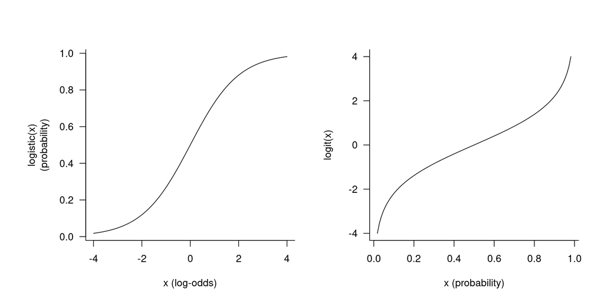

- `qlogis()` function (`plogis()` is logistic/inverse-link)
- *log-odds* ($\log(p/(1-p))$)
- most natural scale for probability calculations
- interpretation depends on *base probability*
  - small probability: like log (proportional)
  - large probability: like log(1-p)
  - intermediate ($0.3 <p <0.7$): effect $\approx \beta/4$

## binomial models

- for Poisson, Bernoulli responses we only need one piece of information
- how do we specify denominator ($N$ in $k/N$)?
  - traditional R: response is two-column matrix of successes and failures [`cbind(k,N-k)` **not** `cbind(k,N)`]
  - also allowed: response is proportion ($k/N$), also specify `weights=N`
  - if equal for all cases and specified on the fly need to replicate:  
    `glm(p~...,data,weights=rep(N,nrow(data)))`

## diagnostics

- harder than linear models: `plot` is still somewhat useful
- binary data especially hard (e.g. `arm::binnedplot`)
- goodness of fit tests, $R^2$ etc. hard (can always compute `cor(observed,predict(model, type="response"))`)
- residuals are *Pearson residuals* by default ($(\textrm{obs}-\textrm{exp})/V(\textrm{exp})$); predicted values are on the effect scale (e.g. log/logit) by default (use `type="response"` to get data-scale predictions)
- also see `DHARMa` package

## what to do about problems

- consider problems *in order*: bias > heterosced. > outliers > distribution > overdisp.
- bias: add covariates? polynomial or spline (GAM) predictors? change link function?
- heteroscedasticity: change variance relationship? (NB1 vs NB2)
- outliers: drop outliers? robust methods?

## overdispersion

- too much variance (after fixing other problems)
- should have residual df $\approx$ residual deviance
- slightly better test: sum of squares of Pearson residuals $\sim \chi^2$
- `aods3::gof()`
- overdispersion < 1.05 (small); >5 maybe something wrong?

## overdispersion: solutions

- **quasilikelihood**: adjust standard errors, CIs, p-values
  - Wald tests only (see below)
- overdispersed distributions (e.g. negative binomial, beta-binomial)
- observation-level random effects (later)

## back-transformation

- confidence intervals are symmetric on link scale
- can back-transform estimates and CIs for log
- logit is hard (must pick a reference level)
- don’t back-transform standard errors!

## estimation

- iteratively re-weighted least-squares
- usually Just Works

## inference

like LMs, but:

- one-parameter tests are usually $Z$ rather than $t$
- CIs based on standard errors are approximate (Wald)
- `confint.glm()` computes *likelihood profile* CIs

## Common(est?) `glm()` problems

- binomial/Poisson models with non-integer data
- failing to specify `family` (default Gaussian: $\to$ linear model); using `glm()` for linear models (unnecessary)
- predictions on effect scale
- using $(k,N)$ rather than $(k,N-k)$ with `family=binomial`
- back-transforming SEs rather than CIs
- neglecting overdispersion
- Poisson for *underdispersed* responses
- equating negative binomial with binomial rather than Poisson
- worrying about overdispersion unnecessarily (binary/Gamma)
- ignoring random effects

# Example

## AIDS (Australia: Dobson & Barnett)

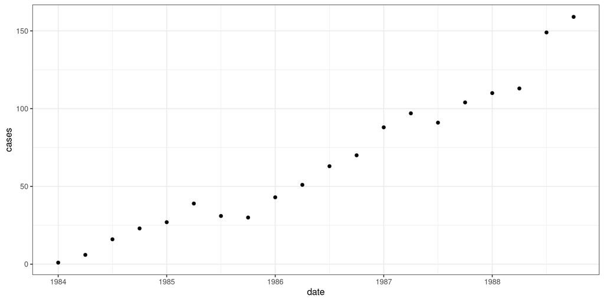

```r
aids <- read.csv("../../data/aids.csv")
## set up time variable
aids <- transform(aids, date=year+(quarter-1)/4)
print(gg0 <- ggplot(aids,aes(date,cases))+geom_point())
```

## Easy GLMs with ggplot

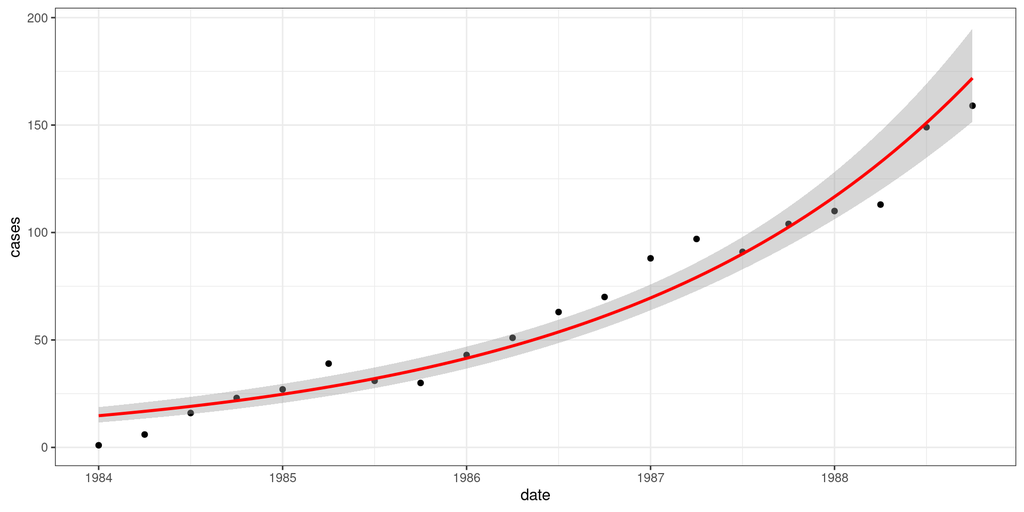

```r
print(gg1 <- gg0 + geom_smooth(method="glm",colour="red",
          method.args=list(family="quasipoisson")))
```

## Equivalent code

```r
g1 <- glm(cases~date,aids,family=quasipoisson(link="log"))
summary(g1)
```

```
##
## Call:
## glm(formula = cases ~ date, family = quasipoisson(link = "log"),
##     data = aids)
##
## Coefficients:
##               Estimate Std. Error t value Pr(>|t|)
## (Intercept) -1.023e+03  6.806e+01  -15.03 1.25e-11 ***
## date         5.168e-01  3.425e-02   15.09 1.16e-11 ***
## ---
## Signif. codes:  0 '***' 0.001 '**' 0.01 '*' 0.05 '.' 0.1 ' ' 1
##
## (Dispersion parameter for quasipoisson family taken to be 2.354647)
##
##     Null deviance: 677.26  on 19  degrees of freedom
## Residual deviance:  53.02  on 18  degrees of freedom
## AIC: NA
##
## Number of Fisher Scoring iterations: 4
```

Note `NA` value for AIC …

## Diagnostics (`plot(g1)`)

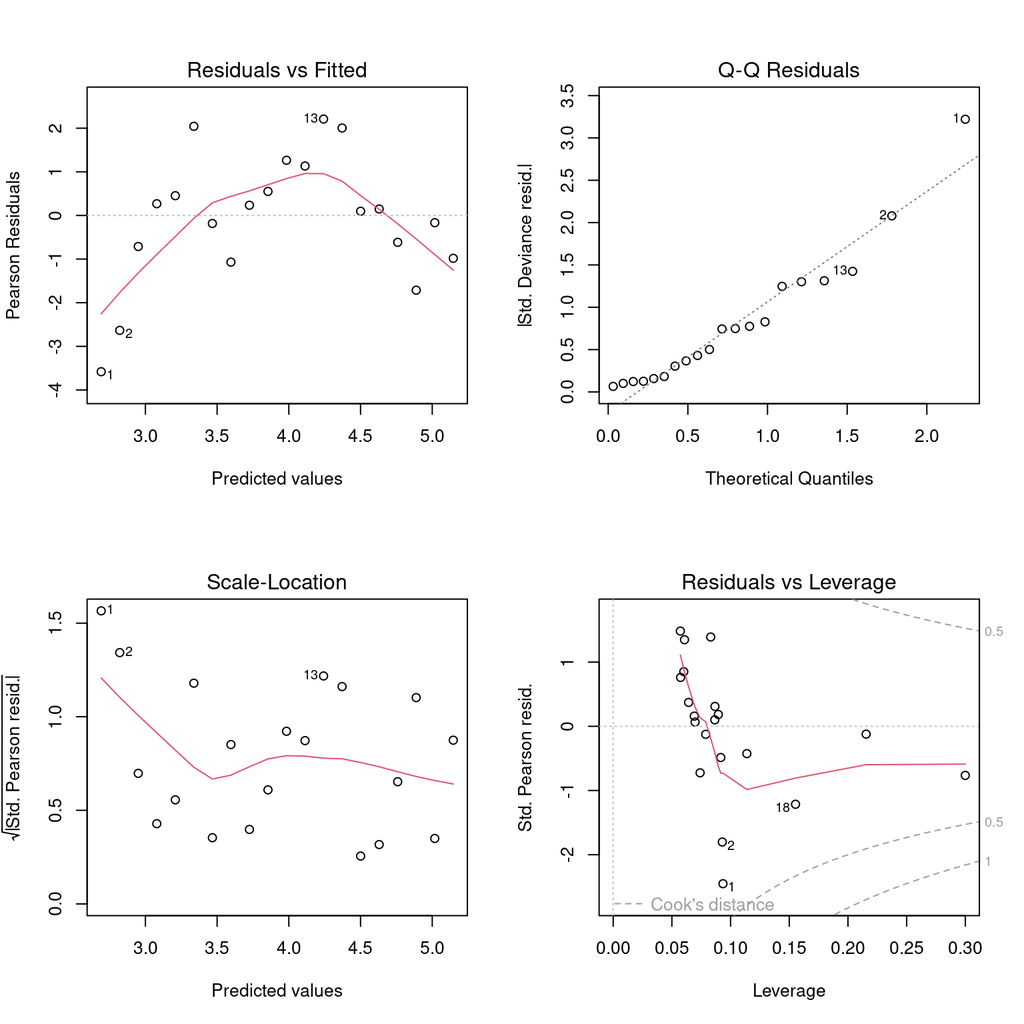

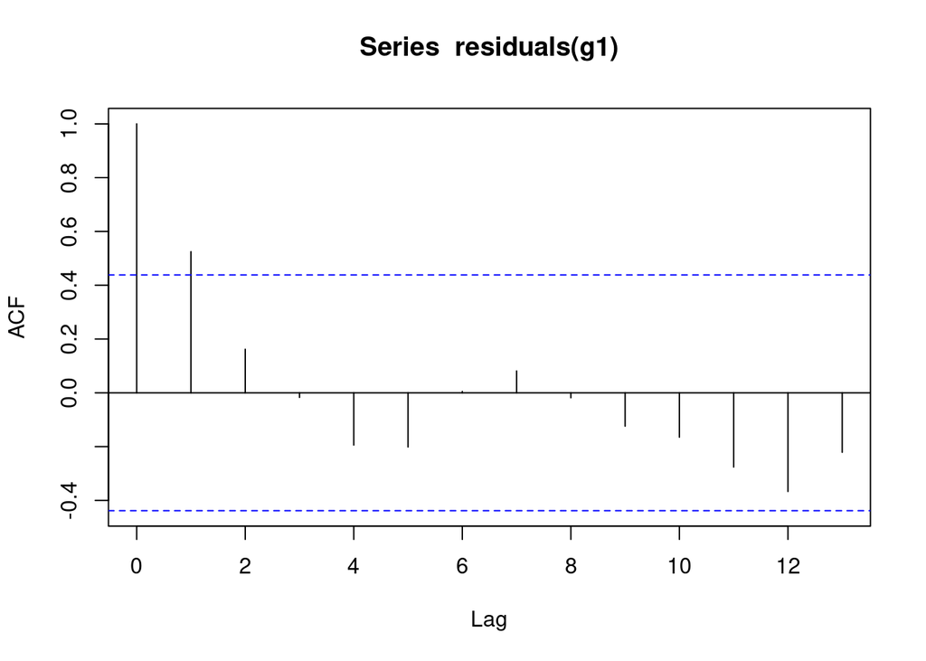

```r
acf(residuals(g1)) ## check autocorrelation
```

## Diagnostics: the Big Lie

- null-hypothesis testing of assumptions is iffy
  - never reject for small data sets
  - always reject for large data sets
- but how do you know how large a problem to worry about?
- gold standard: make your model more complex to show you didn’t need to worry in the first place

## ggplot: check out quadratic model

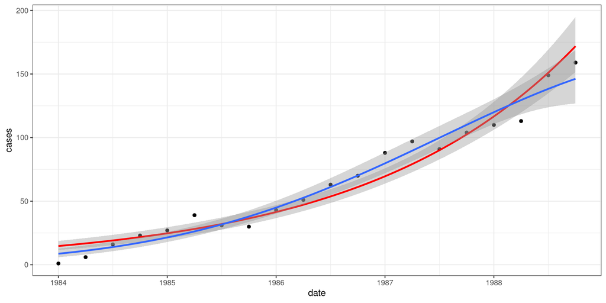

```r
print(gg2 <- gg1+geom_smooth(method="glm",formula=y~poly(x,2),
            method.args=list(family="quasipoisson")))
```

## on log scale

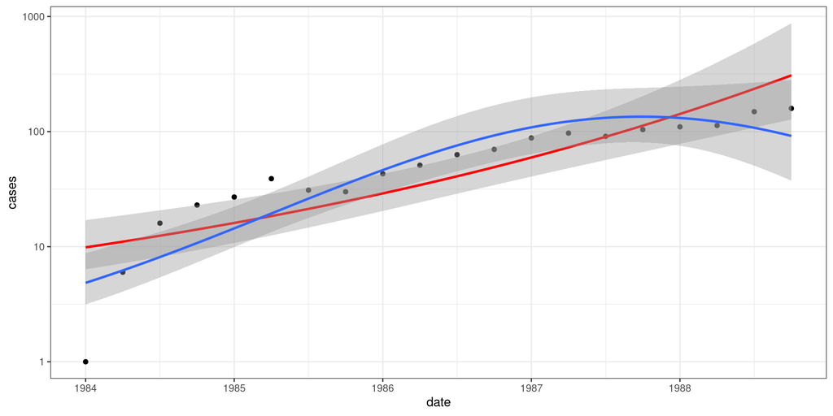

```r
print(gg2+scale_y_log10())
```

## improved model

```r
g2 <- update(g1,.~poly(date,2))
summary(g2)
```

```
##
## Call:
## glm(formula = cases ~ poly(date, 2), family = quasipoisson(link = "log"),
##     data = aids)
##
## Coefficients:
##                Estimate Std. Error t value Pr(>|t|)
## (Intercept)     3.86859    0.05004  77.311  < 2e-16 ***
## poly(date, 2)1  3.82934    0.25162  15.219 2.46e-11 ***
## poly(date, 2)2 -0.68335    0.19716  -3.466  0.00295 **
## ---
## Signif. codes:  0 '***' 0.001 '**' 0.01 '*' 0.05 '.' 0.1 ' ' 1
##
## (Dispersion parameter for quasipoisson family taken to be 1.657309)
##
##     Null deviance: 677.264  on 19  degrees of freedom
## Residual deviance:  31.992  on 17  degrees of freedom
## AIC: NA
##
## Number of Fisher Scoring iterations: 4
```

```r
anova(g1,g2,test="F") ## for quasi-models specifically
```

```
## Analysis of Deviance Table
##
## Model 1: cases ~ date
## Model 2: cases ~ poly(date, 2)
##   Resid. Df Resid. Dev Df Deviance      F   Pr(>F)
## 1        18     53.020
## 2        17     31.992  1   21.028 12.688 0.002399 **
## ---
## Signif. codes:  0 '***' 0.001 '**' 0.01 '*' 0.05 '.' 0.1 ' ' 1
```

## new diagnostics

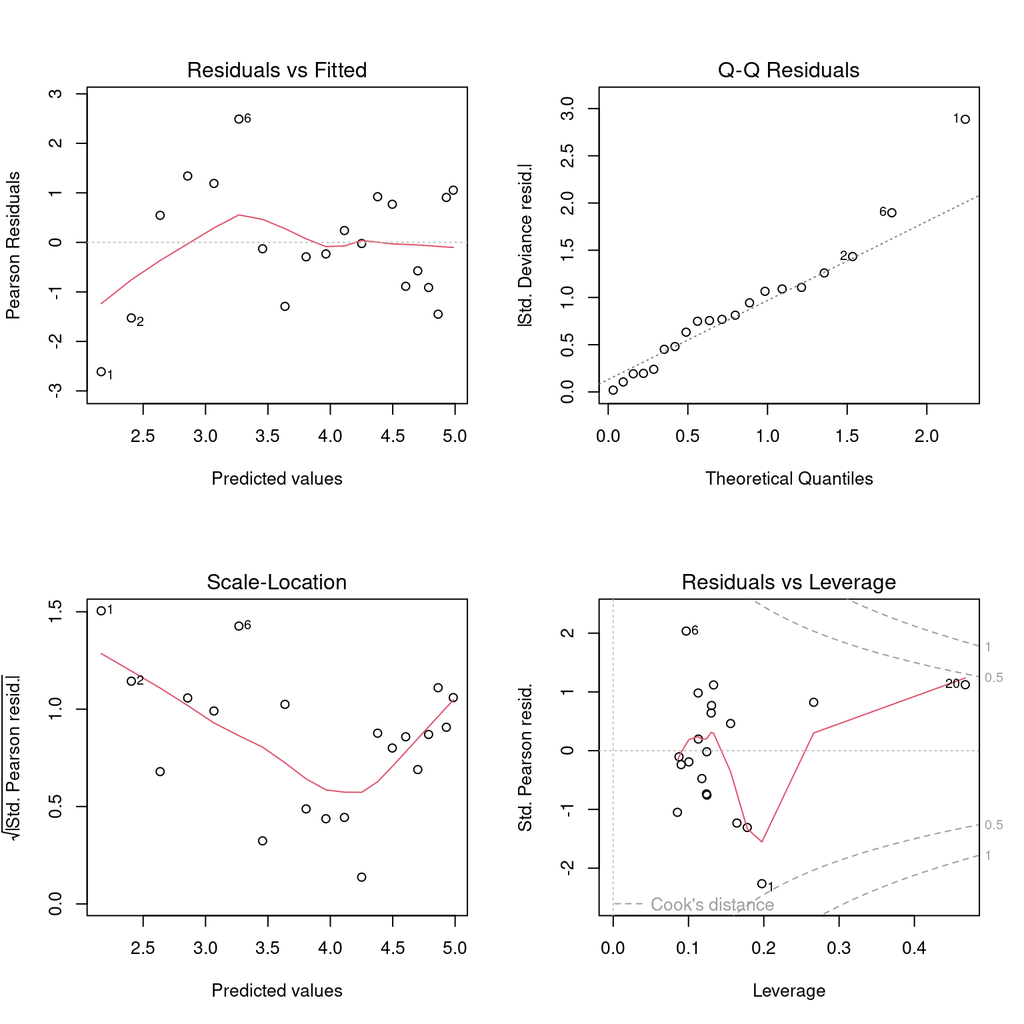

## autocorrelation function

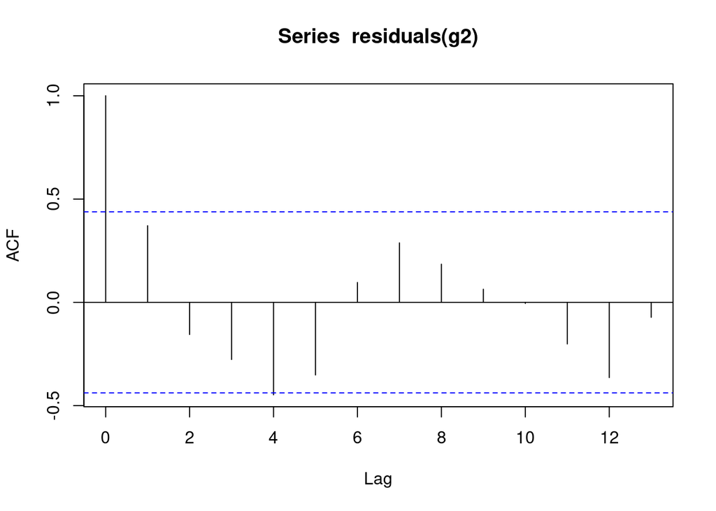

```r
acf(residuals(g2)) ## check autocorrelation
```

Also see `nlme::ACF` for ACFs of grouped data …

## exercise

- pick a data set (from the course data sets if you like; OK to ignore grouping/clustering for now)
- decide on a family and set of predictors
- decide on predictors
- fit a model
- look at diagnostics
- fix the problems?

What did you learn? Where did you get stuck?